# 02_AssignASVs

2025-03-10

# Goals

1. Infer an error model for in the filtered sequences, separately on forward and reverse reads.
2. Assign ASVs on both forward and reverse reads separately by applying the error model.
3. Merge forward and reverse ASVs into “contiguous ASVs”.
4. Generate the first draft of ASV count table.
5. Quality Trimming of ASV lengths.
6. Remove chimeras.
7. Assign Taxonomy with Silva Database.
8. Write out relevant files: `asv_table`, `asvs_fasta`, `tax_table`, and `sample_data`.

## Input

1. Filtered fastq files generated from `01_QualityTrimming.Rmd`.
2. Sample Name vector.

## Output

1. ASV Count Table: `asv_table` (with and without sequence names)
2. ASV fasta file: `asvs_fasta` for building a phylogenetic tree at a later step.
3. Taxonomy Table `tax_table`
4. Sample Information: `sample_data` track the reads lots throughout DADA2 workflow.

# Set up the Environment

## Set Seed & Threads

```r
# Set the seed for reproducibility
set.seed(20020718)

# Let's make a parameter to set the number of threads
n_threads = 20
```

## Timing of this script

```r
# What time did we start running this script?
start_time <- Sys.time()
```

## Load Packages

```r
# Efficient package loading with pacman
pacman::p_load(tidyverse, devtools, dada2,
               patchwork, DT, install = FALSE)
```

## Load Filtered Fastq Files

```r
# Place filtered seq files into a variable
filtered_fastqs_path <- "data/01_DADA2/02_filtered_fastqs"

# Intuition check:
filtered_fastqs_path
```

```
## [1] "data/01_DADA2/02_filtered_fastqs"
```

```r
# Create Forward vector
filtered_forward_reads <-
  list.files(filtered_fastqs_path, pattern = "R1_filtered.fastq.gz",
             full.names = TRUE)
# Check
filtered_forward_reads[1:5]
```

```
## [1] "data/01_DADA2/02_filtered_fastqs/SRR13675761_R1_filtered.fastq.gz"
## [2] "data/01_DADA2/02_filtered_fastqs/SRR13675762_R1_filtered.fastq.gz"
## [3] "data/01_DADA2/02_filtered_fastqs/SRR13675763_R1_filtered.fastq.gz"
## [4] "data/01_DADA2/02_filtered_fastqs/SRR13675764_R1_filtered.fastq.gz"
## [5] "data/01_DADA2/02_filtered_fastqs/SRR13675765_R1_filtered.fastq.gz"
```

```r
# Reverse vector
filtered_reverse_reads <-
    list.files(filtered_fastqs_path, pattern = "R2_filtered.fastq.gz",
             full.names = TRUE)

# Check
filtered_reverse_reads[1:5]
```

```
## [1] "data/01_DADA2/02_filtered_fastqs/SRR13675761_R2_filtered.fastq.gz"
## [2] "data/01_DADA2/02_filtered_fastqs/SRR13675762_R2_filtered.fastq.gz"
## [3] "data/01_DADA2/02_filtered_fastqs/SRR13675763_R2_filtered.fastq.gz"
## [4] "data/01_DADA2/02_filtered_fastqs/SRR13675764_R2_filtered.fastq.gz"
## [5] "data/01_DADA2/02_filtered_fastqs/SRR13675765_R2_filtered.fastq.gz"
```

## Sample Names

```r
# Create vector of sample names from the filenames
sample_names <- sapply(strsplit(basename(filtered_forward_reads), "_"), `[`,1)

# Intuition Check
head(sample_names)
```

```
## [1] "SRR13675761" "SRR13675762" "SRR13675763" "SRR13675764" "SRR13675765"
## [6] "SRR13675766"
```

# Error Modelling

```r
# Forward Reads
error_forward_reads <-
  learnErrors(filtered_forward_reads, multithread = n_threads)
```

```
## 105698943 total bases in 390033 reads from 13 samples will be used for learning the error rates.
```

```r
# Forward Error Plot
forward_error_plot <-
  plotErrors(error_forward_reads, nominalQ = TRUE) +
  labs(title = "Forward Reads: Error Model")

# Reverse Reads
error_reverse_reads <-
  learnErrors(filtered_reverse_reads, multithread = n_threads)
```

```
## 100628514 total bases in 390033 reads from 13 samples will be used for learning the error rates.
```

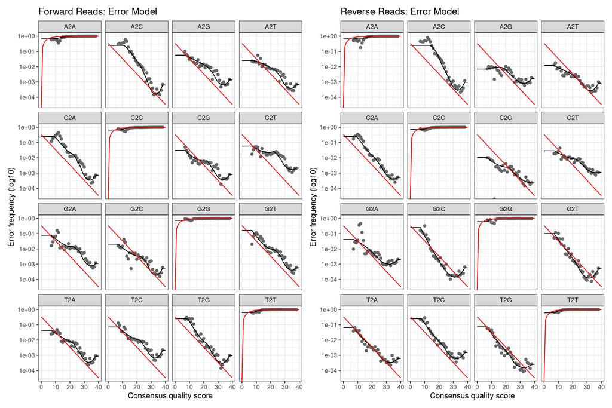

```r
# Reverse Error Plot
reverse_error_plot <-
  plotErrors(error_reverse_reads, nominalQ = TRUE) +
  labs(title = "Reverse Reads: Error Model")

# Look at the plots together
forward_error_plot + reverse_error_plot
```

# Infer ASVs

```r
# Infer ASVs on the forward sequences
dada_forward <-
  dada(filtered_forward_reads,
       err = error_forward_reads,
       multithread = n_threads)
```

```
## Sample 1 - 32018 reads in 7963 unique sequences.
## Sample 2 - 49289 reads in 13714 unique sequences.
## Sample 3 - 38887 reads in 3808 unique sequences.
## Sample 4 - 37756 reads in 6980 unique sequences.
## Sample 5 - 30076 reads in 3066 unique sequences.
## Sample 6 - 571 reads in 211 unique sequences.
## Sample 7 - 49783 reads in 8979 unique sequences.
## Sample 8 - 11015 reads in 1849 unique sequences.
## Sample 9 - 34889 reads in 5872 unique sequences.
## Sample 10 - 36573 reads in 5907 unique sequences.
## Sample 11 - 1470 reads in 354 unique sequences.
## Sample 12 - 28456 reads in 4617 unique sequences.
## Sample 13 - 39250 reads in 6165 unique sequences.
## Sample 14 - 36432 reads in 6079 unique sequences.
## Sample 15 - 1601 reads in 376 unique sequences.
## Sample 16 - 39831 reads in 4725 unique sequences.
## Sample 17 - 2 reads in 2 unique sequences.
## Sample 18 - 18123 reads in 3079 unique sequences.
## Sample 19 - 40346 reads in 5142 unique sequences.
## Sample 20 - 818 reads in 203 unique sequences.
## Sample 21 - 25373 reads in 2968 unique sequences.
## Sample 22 - 41270 reads in 6600 unique sequences.
## Sample 23 - 39176 reads in 6144 unique sequences.
## Sample 24 - 6628 reads in 1219 unique sequences.
## Sample 25 - 34613 reads in 4149 unique sequences.
## Sample 26 - 41548 reads in 8486 unique sequences.
## Sample 27 - 35840 reads in 6891 unique sequences.
## Sample 28 - 36884 reads in 2284 unique sequences.
## Sample 29 - 38885 reads in 7110 unique sequences.
## Sample 30 - 39169 reads in 6489 unique sequences.
## Sample 31 - 41775 reads in 6180 unique sequences.
## Sample 32 - 12 reads in 11 unique sequences.
## Sample 33 - 7079 reads in 750 unique sequences.
## Sample 34 - 27569 reads in 5287 unique sequences.
## Sample 35 - 36155 reads in 4476 unique sequences.
## Sample 36 - 43145 reads in 6134 unique sequences.
## Sample 37 - 29624 reads in 4503 unique sequences.
## Sample 38 - 44171 reads in 1718 unique sequences.
## Sample 39 - 31651 reads in 5896 unique sequences.
## Sample 40 - 41617 reads in 8010 unique sequences.
```

[output cut: 131 more lines]

```
## Sample 172 - 18435 reads in 2985 unique sequences.
## Sample 173 - 28489 reads in 4445 unique sequences.
## Sample 174 - 140950 reads in 18764 unique sequences.
## Sample 175 - 108581 reads in 11236 unique sequences.
## Sample 176 - 71213 reads in 3202 unique sequences.
## Sample 177 - 16753 reads in 2320 unique sequences.
## Sample 178 - 94761 reads in 14478 unique sequences.
## Sample 179 - 87825 reads in 13244 unique sequences.
## Sample 180 - 9558 reads in 1419 unique sequences.
## Sample 181 - 113923 reads in 15560 unique sequences.
## Sample 182 - 34433 reads in 6653 unique sequences.
## Sample 183 - 88690 reads in 8866 unique sequences.
## Sample 184 - 12975 reads in 1805 unique sequences.
## Sample 185 - 92229 reads in 11180 unique sequences.
## Sample 186 - 60692 reads in 10377 unique sequences.
```

```r
# Take a look at the data
# What type of data structure is it?
typeof(dada_forward) # It's a list
```

```
## [1] "list"
```

```r
length(dada_forward) # How big is it? One per sample!
```

```
## [1] 186
```

```r
# What doees it look like for each sample?
dada_forward$`20210602-MA-CES1F_R1_filtered.fastq.gz`
```

[output not shown]

```r
# Reverse ASVs
dada_reverse <-
  dada(filtered_reverse_reads,
       err = error_reverse_reads ,
       multithread = n_threads)
```

```
## Sample 1 - 32018 reads in 10526 unique sequences.
## Sample 2 - 49289 reads in 17187 unique sequences.
## Sample 3 - 38887 reads in 5123 unique sequences.
## Sample 4 - 37756 reads in 6732 unique sequences.
## Sample 5 - 30076 reads in 3614 unique sequences.
## Sample 6 - 571 reads in 241 unique sequences.
## Sample 7 - 49783 reads in 9740 unique sequences.
## Sample 8 - 11015 reads in 2106 unique sequences.
## Sample 9 - 34889 reads in 6598 unique sequences.
## Sample 10 - 36573 reads in 7115 unique sequences.
## Sample 11 - 1470 reads in 520 unique sequences.
## Sample 12 - 28456 reads in 5459 unique sequences.
## Sample 13 - 39250 reads in 7489 unique sequences.
## Sample 14 - 36432 reads in 6965 unique sequences.
## Sample 15 - 1601 reads in 458 unique sequences.
## Sample 16 - 39831 reads in 7328 unique sequences.
## Sample 17 - 2 reads in 2 unique sequences.
## Sample 18 - 18123 reads in 3662 unique sequences.
## Sample 19 - 40346 reads in 6990 unique sequences.
## Sample 20 - 818 reads in 304 unique sequences.
## Sample 21 - 25373 reads in 4151 unique sequences.
## Sample 22 - 41270 reads in 7545 unique sequences.
## Sample 23 - 39176 reads in 6579 unique sequences.
## Sample 24 - 6628 reads in 1680 unique sequences.
## Sample 25 - 34613 reads in 5529 unique sequences.
## Sample 26 - 41548 reads in 9713 unique sequences.
## Sample 27 - 35840 reads in 7841 unique sequences.
## Sample 28 - 36884 reads in 3373 unique sequences.
## Sample 29 - 38885 reads in 8380 unique sequences.
## Sample 30 - 39169 reads in 8178 unique sequences.
## Sample 31 - 41775 reads in 6959 unique sequences.
## Sample 32 - 12 reads in 11 unique sequences.
## Sample 33 - 7079 reads in 1078 unique sequences.
## Sample 34 - 27569 reads in 6270 unique sequences.
## Sample 35 - 36155 reads in 5998 unique sequences.
## Sample 36 - 43145 reads in 7434 unique sequences.
## Sample 37 - 29624 reads in 5833 unique sequences.
## Sample 38 - 44171 reads in 2908 unique sequences.
## Sample 39 - 31651 reads in 6782 unique sequences.
## Sample 40 - 41617 reads in 8681 unique sequences.
```

[output cut: 131 more lines]

```
## Sample 172 - 18435 reads in 4060 unique sequences.
## Sample 173 - 28489 reads in 6705 unique sequences.
## Sample 174 - 140950 reads in 22980 unique sequences.
## Sample 175 - 108581 reads in 15199 unique sequences.
## Sample 176 - 71213 reads in 5765 unique sequences.
## Sample 177 - 16753 reads in 3610 unique sequences.
## Sample 178 - 94761 reads in 17603 unique sequences.
## Sample 179 - 87825 reads in 16646 unique sequences.
## Sample 180 - 9558 reads in 2083 unique sequences.
## Sample 181 - 113923 reads in 18661 unique sequences.
## Sample 182 - 34433 reads in 6695 unique sequences.
## Sample 183 - 88690 reads in 12932 unique sequences.
## Sample 184 - 12975 reads in 2984 unique sequences.
## Sample 185 - 92229 reads in 14537 unique sequences.
## Sample 186 - 60692 reads in 13289 unique sequences.
```

```r
# Check data
dada_reverse[30]
```

```
## $SRR13675790_R2_filtered.fastq.gz
## dada-class: object describing DADA2 denoising results
## 265 sequence variants were inferred from 8178 input unique sequences.
## Key parameters: OMEGA_A = 1e-40, OMEGA_C = 1e-40, BAND_SIZE = 16
```

# Merge Forward and Reverse ASVs

```r
merged_ASVs <-
  mergePairs(dada_forward, filtered_forward_reads,
             dada_reverse, filtered_reverse_reads,
             verbose = TRUE)
```

```
## 27722 paired-reads (in 714 unique pairings) successfully merged out of 29701 (in 1299 pairings) input.
```

```
## 40964 paired-reads (in 1127 unique pairings) successfully merged out of 45312 (in 2389 pairings) input.
```

```
## 38394 paired-reads (in 179 unique pairings) successfully merged out of 38601 (in 250 pairings) input.
```

```
## 35837 paired-reads (in 344 unique pairings) successfully merged out of 36839 (in 728 pairings) input.
```

```
## 29711 paired-reads (in 105 unique pairings) successfully merged out of 29785 (in 143 pairings) input.
```

```
## 481 paired-reads (in 35 unique pairings) successfully merged out of 503 (in 40 pairings) input.
```

```
## 47360 paired-reads (in 448 unique pairings) successfully merged out of 48322 (in 848 pairings) input.
```

```
## 10682 paired-reads (in 92 unique pairings) successfully merged out of 10744 (in 112 pairings) input.
```

```
## 33126 paired-reads (in 282 unique pairings) successfully merged out of 33814 (in 552 pairings) input.
```

```
## 34898 paired-reads (in 265 unique pairings) successfully merged out of 35587 (in 533 pairings) input.
```

```
## 1369 paired-reads (in 54 unique pairings) successfully merged out of 1403 (in 55 pairings) input.
```

```
## 27819 paired-reads (in 249 unique pairings) successfully merged out of 28046 (in 344 pairings) input.
```

```
## 37645 paired-reads (in 280 unique pairings) successfully merged out of 38195 (in 522 pairings) input.
```

```
## 34925 paired-reads (in 286 unique pairings) successfully merged out of 35340 (in 490 pairings) input.
```

```
## 1510 paired-reads (in 48 unique pairings) successfully merged out of 1530 (in 55 pairings) input.
```

```
## 38919 paired-reads (in 289 unique pairings) successfully merged out of 39292 (in 378 pairings) input.
```

```
## 1 paired-reads (in 1 unique pairings) successfully merged out of 1 (in 1 pairings) input.
```

```
## 17408 paired-reads (in 212 unique pairings) successfully merged out of 17743 (in 293 pairings) input.
```

```
## 39221 paired-reads (in 277 unique pairings) successfully merged out of 39758 (in 434 pairings) input.
```

```
## 758 paired-reads (in 33 unique pairings) successfully merged out of 758 (in 33 pairings) input.
```

```
## 25117 paired-reads (in 136 unique pairings) successfully merged out of 25239 (in 172 pairings) input.
```

```
## 39554 paired-reads (in 377 unique pairings) successfully merged out of 40334 (in 645 pairings) input.
```

```
## 37928 paired-reads (in 330 unique pairings) successfully merged out of 38460 (in 534 pairings) input.
```

```
## 6284 paired-reads (in 102 unique pairings) successfully merged out of 6366 (in 127 pairings) input.
```

```
## 33864 paired-reads (in 220 unique pairings) successfully merged out of 34123 (in 324 pairings) input.
```

```
## 38503 paired-reads (in 458 unique pairings) successfully merged out of 39707 (in 1030 pairings) input.
```

```
## 33901 paired-reads (in 358 unique pairings) successfully merged out of 34526 (in 657 pairings) input.
```

```
## 36725 paired-reads (in 79 unique pairings) successfully merged out of 36766 (in 101 pairings) input.
```

```
## 36800 paired-reads (in 361 unique pairings) successfully merged out of 37619 (in 633 pairings) input.
```

```
## 37728 paired-reads (in 359 unique pairings) successfully merged out of 38327 (in 603 pairings) input.
```

```
## 40165 paired-reads (in 312 unique pairings) successfully merged out of 40899 (in 524 pairings) input.
```

```
## 6 paired-reads (in 1 unique pairings) successfully merged out of 6 (in 1 pairings) input.
```

```
## 6963 paired-reads (in 34 unique pairings) successfully merged out of 6990 (in 44 pairings) input.
```

```
## 25958 paired-reads (in 271 unique pairings) successfully merged out of 26658 (in 554 pairings) input.
```

```
## 35587 paired-reads (in 220 unique pairings) successfully merged out of 35801 (in 304 pairings) input.
```

```
## 41599 paired-reads (in 366 unique pairings) successfully merged out of 42364 (in 596 pairings) input.
```

```
## 28435 paired-reads (in 264 unique pairings) successfully merged out of 29042 (in 428 pairings) input.
```

```
## 44066 paired-reads (in 19 unique pairings) successfully merged out of 44103 (in 35 pairings) input.
```

```
## 29284 paired-reads (in 307 unique pairings) successfully merged out of 30569 (in 771 pairings) input.
```

```
## 39301 paired-reads (in 409 unique pairings) successfully merged out of 40089 (in 744 pairings) input.
```

```
## 34011 paired-reads (in 321 unique pairings) successfully merged out of 34789 (in 673 pairings) input.
```

```
## 32423 paired-reads (in 331 unique pairings) successfully merged out of 33126 (in 638 pairings) input.
```

```
## 713 paired-reads (in 32 unique pairings) successfully merged out of 734 (in 38 pairings) input.
```

```
## 4433 paired-reads (in 114 unique pairings) successfully merged out of 4499 (in 134 pairings) input.
```

```
## 61006 paired-reads (in 422 unique pairings) successfully merged out of 61948 (in 788 pairings) input.
```

```
## 19653 paired-reads (in 190 unique pairings) successfully merged out of 19993 (in 307 pairings) input.
```

```
## 30020 paired-reads (in 314 unique pairings) successfully merged out of 30740 (in 522 pairings) input.
```

```
## 34574 paired-reads (in 293 unique pairings) successfully merged out of 35247 (in 570 pairings) input.
```

```
## 26134 paired-reads (in 279 unique pairings) successfully merged out of 26842 (in 527 pairings) input.
```

```
## 18307 paired-reads (in 102 unique pairings) successfully merged out of 18524 (in 174 pairings) input.
```

```
## 35707 paired-reads (in 338 unique pairings) successfully merged out of 36358 (in 597 pairings) input.
```

```
## 24983 paired-reads (in 518 unique pairings) successfully merged out of 26242 (in 866 pairings) input.
```

```
## 27720 paired-reads (in 281 unique pairings) successfully merged out of 28695 (in 691 pairings) input.
```

```
## 49451 paired-reads (in 377 unique pairings) successfully merged out of 51193 (in 942 pairings) input.
```

```
## 1663 paired-reads (in 57 unique pairings) successfully merged out of 1696 (in 68 pairings) input.
```

```
## 35497 paired-reads (in 67 unique pairings) successfully merged out of 36556 (in 98 pairings) input.
```

```
## 41945 paired-reads (in 498 unique pairings) successfully merged out of 44413 (in 1325 pairings) input.
```

```
## 71727 paired-reads (in 609 unique pairings) successfully merged out of 75260 (in 1672 pairings) input.
```

```
## 29238 paired-reads (in 248 unique pairings) successfully merged out of 29690 (in 484 pairings) input.
```

```
## 46323 paired-reads (in 43 unique pairings) successfully merged out of 47735 (in 69 pairings) input.
```

```
## 42815 paired-reads (in 76 unique pairings) successfully merged out of 44087 (in 118 pairings) input.
```

```
## 70358 paired-reads (in 657 unique pairings) successfully merged out of 74475 (in 1834 pairings) input.
```

```
## 7691 paired-reads (in 106 unique pairings) successfully merged out of 8361 (in 286 pairings) input.
```

```
## 1370 paired-reads (in 33 unique pairings) successfully merged out of 1397 (in 41 pairings) input.
```

```
## 10409 paired-reads (in 109 unique pairings) successfully merged out of 10472 (in 123 pairings) input.
```

```
## 94664 paired-reads (in 964 unique pairings) successfully merged out of 99701 (in 2516 pairings) input.
```

```
## 58948 paired-reads (in 626 unique pairings) successfully merged out of 62009 (in 1601 pairings) input.
```

```
## 32057 paired-reads (in 96 unique pairings) successfully merged out of 33082 (in 127 pairings) input.
```

```
## 44554 paired-reads (in 54 unique pairings) successfully merged out of 45980 (in 98 pairings) input.
```

```
## 35854 paired-reads (in 294 unique pairings) successfully merged out of 36304 (in 519 pairings) input.
```

```
## 68062 paired-reads (in 630 unique pairings) successfully merged out of 72154 (in 1480 pairings) input.
```

```
## 52543 paired-reads (in 459 unique pairings) successfully merged out of 55408 (in 1086 pairings) input.
```

```
## 3845 paired-reads (in 54 unique pairings) successfully merged out of 3926 (in 69 pairings) input.
```

```
## 57213 paired-reads (in 109 unique pairings) successfully merged out of 58971 (in 139 pairings) input.
```

```
## 97048 paired-reads (in 982 unique pairings) successfully merged out of 103952 (in 2678 pairings) input.
```

```
## 65860 paired-reads (in 432 unique pairings) successfully merged out of 69547 (in 944 pairings) input.
```

```
## 33483 paired-reads (in 64 unique pairings) successfully merged out of 34435 (in 123 pairings) input.
```

```
## 54210 paired-reads (in 286 unique pairings) successfully merged out of 56666 (in 661 pairings) input.
```

```
## 75549 paired-reads (in 522 unique pairings) successfully merged out of 78781 (in 1339 pairings) input.
```

```
## 71094 paired-reads (in 490 unique pairings) successfully merged out of 74030 (in 1309 pairings) input.
```

```
## 9722 paired-reads (in 159 unique pairings) successfully merged out of 10027 (in 249 pairings) input.
```

```
## 1863 paired-reads (in 43 unique pairings) successfully merged out of 1887 (in 53 pairings) input.
```

```
## 105394 paired-reads (in 371 unique pairings) successfully merged out of 108954 (in 603 pairings) input.
```

```
## 63623 paired-reads (in 592 unique pairings) successfully merged out of 68111 (in 1894 pairings) input.
```

```
## 75388 paired-reads (in 546 unique pairings) successfully merged out of 79625 (in 1713 pairings) input.
```

```
## 33562 paired-reads (in 44 unique pairings) successfully merged out of 34486 (in 73 pairings) input.
```

```
## 41899 paired-reads (in 70 unique pairings) successfully merged out of 43201 (in 107 pairings) input.
```

```
## 59894 paired-reads (in 451 unique pairings) successfully merged out of 62360 (in 1004 pairings) input.
```

```
## 34069 paired-reads (in 277 unique pairings) successfully merged out of 36425 (in 555 pairings) input.
```

```
## 1685 paired-reads (in 32 unique pairings) successfully merged out of 1721 (in 43 pairings) input.
```

```
## 21373 paired-reads (in 210 unique pairings) successfully merged out of 22391 (in 349 pairings) input.
```

```
## 38884 paired-reads (in 345 unique pairings) successfully merged out of 39381 (in 552 pairings) input.
```

```
## 59703 paired-reads (in 328 unique pairings) successfully merged out of 62789 (in 635 pairings) input.
```

```
## 55192 paired-reads (in 430 unique pairings) successfully merged out of 57387 (in 838 pairings) input.
```

```
## 58148 paired-reads (in 629 unique pairings) successfully merged out of 61472 (in 1217 pairings) input.
```

```
## 32395 paired-reads (in 235 unique pairings) successfully merged out of 34170 (in 513 pairings) input.
```

```
## 66781 paired-reads (in 458 unique pairings) successfully merged out of 70159 (in 1474 pairings) input.
```

```
## 63848 paired-reads (in 417 unique pairings) successfully merged out of 66414 (in 1224 pairings) input.
```

```
## 56435 paired-reads (in 80 unique pairings) successfully merged out of 58083 (in 103 pairings) input.
```

```
## 57223 paired-reads (in 271 unique pairings) successfully merged out of 59146 (in 428 pairings) input.
```

```
## 79603 paired-reads (in 440 unique pairings) successfully merged out of 83360 (in 1176 pairings) input.
```

```
## 44193 paired-reads (in 99 unique pairings) successfully merged out of 45527 (in 152 pairings) input.
```

```
## 31668 paired-reads (in 338 unique pairings) successfully merged out of 32499 (in 711 pairings) input.
```

```
## 70627 paired-reads (in 45 unique pairings) successfully merged out of 72810 (in 70 pairings) input.
```

```
## 41817 paired-reads (in 208 unique pairings) successfully merged out of 43203 (in 337 pairings) input.
```

```
## 75081 paired-reads (in 608 unique pairings) successfully merged out of 78398 (in 1605 pairings) input.
```

```
## 75871 paired-reads (in 529 unique pairings) successfully merged out of 78494 (in 1203 pairings) input.
```

```
## 50429 paired-reads (in 50 unique pairings) successfully merged out of 51891 (in 75 pairings) input.
```

```
## 44862 paired-reads (in 217 unique pairings) successfully merged out of 46551 (in 370 pairings) input.
```

```
## 61787 paired-reads (in 495 unique pairings) successfully merged out of 64133 (in 1229 pairings) input.
```

```
## 53744 paired-reads (in 410 unique pairings) successfully merged out of 56055 (in 1122 pairings) input.
```

```
## 45573 paired-reads (in 81 unique pairings) successfully merged out of 46925 (in 109 pairings) input.
```

```
## 58081 paired-reads (in 442 unique pairings) successfully merged out of 60644 (in 842 pairings) input.
```

```
## 31528 paired-reads (in 388 unique pairings) successfully merged out of 32421 (in 738 pairings) input.
```

```
## 84413 paired-reads (in 638 unique pairings) successfully merged out of 88313 (in 1422 pairings) input.
```

```
## 66594 paired-reads (in 517 unique pairings) successfully merged out of 69806 (in 1065 pairings) input.
```

```
## 37375 paired-reads (in 53 unique pairings) successfully merged out of 38541 (in 78 pairings) input.
```

```
## 59506 paired-reads (in 414 unique pairings) successfully merged out of 62178 (in 888 pairings) input.
```

```
## 64310 paired-reads (in 535 unique pairings) successfully merged out of 66708 (in 1198 pairings) input.
```

```
## 54846 paired-reads (in 655 unique pairings) successfully merged out of 57682 (in 1663 pairings) input.
```

```
## 73095 paired-reads (in 744 unique pairings) successfully merged out of 76859 (in 1477 pairings) input.
```

```
## 106558 paired-reads (in 600 unique pairings) successfully merged out of 107853 (in 1150 pairings) input.
```

```
## 19640 paired-reads (in 85 unique pairings) successfully merged out of 20228 (in 108 pairings) input.
```

```
## 97001 paired-reads (in 794 unique pairings) successfully merged out of 99008 (in 1623 pairings) input.
```

```
## 6708 paired-reads (in 158 unique pairings) successfully merged out of 6815 (in 208 pairings) input.
```

```
## 85970 paired-reads (in 843 unique pairings) successfully merged out of 87914 (in 1664 pairings) input.
```

```
## 16825 paired-reads (in 32 unique pairings) successfully merged out of 16857 (in 47 pairings) input.
```

```
## 51849 paired-reads (in 167 unique pairings) successfully merged out of 52024 (in 229 pairings) input.
```

```
## 69113 paired-reads (in 574 unique pairings) successfully merged out of 70680 (in 1286 pairings) input.
```

```
## 97726 paired-reads (in 702 unique pairings) successfully merged out of 99658 (in 1550 pairings) input.
```

```
## 35464 paired-reads (in 208 unique pairings) successfully merged out of 35617 (in 283 pairings) input.
```

```
## 71958 paired-reads (in 309 unique pairings) successfully merged out of 72778 (in 601 pairings) input.
```

```
## 133381 paired-reads (in 478 unique pairings) successfully merged out of 134465 (in 909 pairings) input.
```

```
## 72558 paired-reads (in 312 unique pairings) successfully merged out of 73082 (in 530 pairings) input.
```

```
## 75409 paired-reads (in 559 unique pairings) successfully merged out of 76501 (in 1003 pairings) input.
```

```
## 28333 paired-reads (in 292 unique pairings) successfully merged out of 28755 (in 437 pairings) input.
```

```
## 12048 paired-reads (in 66 unique pairings) successfully merged out of 12172 (in 125 pairings) input.
```

```
## 118657 paired-reads (in 823 unique pairings) successfully merged out of 122000 (in 1964 pairings) input.
```

```
## 88329 paired-reads (in 580 unique pairings) successfully merged out of 90355 (in 1225 pairings) input.
```

```
## 37657 paired-reads (in 69 unique pairings) successfully merged out of 37701 (in 85 pairings) input.
```

```
## 12042 paired-reads (in 28 unique pairings) successfully merged out of 12066 (in 36 pairings) input.
```

```
## 59857 paired-reads (in 387 unique pairings) successfully merged out of 60970 (in 743 pairings) input.
```

```
## 88131 paired-reads (in 339 unique pairings) successfully merged out of 88890 (in 554 pairings) input.
```

```
## 91957 paired-reads (in 581 unique pairings) successfully merged out of 93107 (in 941 pairings) input.
```

```
## 56607 paired-reads (in 291 unique pairings) successfully merged out of 57150 (in 419 pairings) input.
```

```
## 95521 paired-reads (in 777 unique pairings) successfully merged out of 97706 (in 1558 pairings) input.
```

```
## 41842 paired-reads (in 415 unique pairings) successfully merged out of 42869 (in 973 pairings) input.
```

```
## 25514 paired-reads (in 223 unique pairings) successfully merged out of 26111 (in 392 pairings) input.
```

```
## 28934 paired-reads (in 388 unique pairings) successfully merged out of 30292 (in 812 pairings) input.
```

```
## 43496 paired-reads (in 486 unique pairings) successfully merged out of 44618 (in 951 pairings) input.
```

```
## 71643 paired-reads (in 248 unique pairings) successfully merged out of 71905 (in 327 pairings) input.
```

```
## 46528 paired-reads (in 171 unique pairings) successfully merged out of 46903 (in 272 pairings) input.
```

```
## 114043 paired-reads (in 708 unique pairings) successfully merged out of 117017 (in 1802 pairings) input.
```

```
## 91943 paired-reads (in 246 unique pairings) successfully merged out of 92274 (in 350 pairings) input.
```

```
## 42953 paired-reads (in 192 unique pairings) successfully merged out of 43143 (in 273 pairings) input.
```

```
## 63157 paired-reads (in 711 unique pairings) successfully merged out of 65402 (in 1659 pairings) input.
```

```
## 55232 paired-reads (in 545 unique pairings) successfully merged out of 57215 (in 1362 pairings) input.
```

```
## 27798 paired-reads (in 192 unique pairings) successfully merged out of 27911 (in 239 pairings) input.
```

```
## 69245 paired-reads (in 396 unique pairings) successfully merged out of 85046 (in 1006 pairings) input.
```

```
## 87902 paired-reads (in 529 unique pairings) successfully merged out of 95402 (in 1437 pairings) input.
```

```
## 67474 paired-reads (in 460 unique pairings) successfully merged out of 68792 (in 891 pairings) input.
```

```
## 54315 paired-reads (in 307 unique pairings) successfully merged out of 54998 (in 512 pairings) input.
```

```
## 6890 paired-reads (in 179 unique pairings) successfully merged out of 6993 (in 214 pairings) input.
```

```
## 34888 paired-reads (in 268 unique pairings) successfully merged out of 35113 (in 343 pairings) input.
```

```
## 70672 paired-reads (in 474 unique pairings) successfully merged out of 72130 (in 1117 pairings) input.
```

```
## 70424 paired-reads (in 444 unique pairings) successfully merged out of 71316 (in 753 pairings) input.
```

```
## 25959 paired-reads (in 151 unique pairings) successfully merged out of 26154 (in 215 pairings) input.
```

```
## 74828 paired-reads (in 516 unique pairings) successfully merged out of 75762 (in 922 pairings) input.
```

```
## 114477 paired-reads (in 691 unique pairings) successfully merged out of 116997 (in 1903 pairings) input.
```

```
## 119426 paired-reads (in 761 unique pairings) successfully merged out of 121877 (in 1959 pairings) input.
```

```
## 4548 paired-reads (in 91 unique pairings) successfully merged out of 4604 (in 98 pairings) input.
```

```
## 17224 paired-reads (in 252 unique pairings) successfully merged out of 17776 (in 412 pairings) input.
```

```
## 27566 paired-reads (in 359 unique pairings) successfully merged out of 28031 (in 470 pairings) input.
```

```
## 134755 paired-reads (in 766 unique pairings) successfully merged out of 137594 (in 1864 pairings) input.
```

```
## 106241 paired-reads (in 418 unique pairings) successfully merged out of 107203 (in 786 pairings) input.
```

```
## 70586 paired-reads (in 149 unique pairings) successfully merged out of 70813 (in 230 pairings) input.
```

```
## 16605 paired-reads (in 178 unique pairings) successfully merged out of 16665 (in 190 pairings) input.
```

```
## 89031 paired-reads (in 898 unique pairings) successfully merged out of 92208 (in 2046 pairings) input.
```

```
## 83662 paired-reads (in 520 unique pairings) successfully merged out of 85427 (in 1226 pairings) input.
```

```
## 9460 paired-reads (in 112 unique pairings) successfully merged out of 9472 (in 117 pairings) input.
```

```
## 108559 paired-reads (in 635 unique pairings) successfully merged out of 111282 (in 1515 pairings) input.
```

```
## 32780 paired-reads (in 341 unique pairings) successfully merged out of 33349 (in 570 pairings) input.
```

```
## 86710 paired-reads (in 276 unique pairings) successfully merged out of 88262 (in 607 pairings) input.
```

```
## 12784 paired-reads (in 158 unique pairings) successfully merged out of 12850 (in 174 pairings) input.
```

```
## 88722 paired-reads (in 501 unique pairings) successfully merged out of 90423 (in 1048 pairings) input.
```

```
## 57888 paired-reads (in 476 unique pairings) successfully merged out of 58973 (in 873 pairings) input.
```

```r
# Evaluate the data output
typeof(merged_ASVs) # A list
```

```
## [1] "list"
```

```r
length(merged_ASVs) # Length of the number of samples!
```

```
## [1] 186
```

```r
head(names(merged_ASVs)) # Here, we can access our current sample names
```

```
## [1] "SRR13675761_R1_filtered.fastq.gz" "SRR13675762_R1_filtered.fastq.gz"
## [3] "SRR13675763_R1_filtered.fastq.gz" "SRR13675764_R1_filtered.fastq.gz"
## [5] "SRR13675765_R1_filtered.fastq.gz" "SRR13675766_R1_filtered.fastq.gz"
```

```r
# Inspect further for each sample
head(merged_ASVs, n = 2) # A dataframe for each sample
```

```
## $SRR13675761_R1_filtered.fastq.gz
##                                                                                                                                                                                                                                                                                                          …
## 1                            GGGAATTTTCCGCAATGGGCGAAAGCCTGACGGAGCAATGCCGCGTGGAGGTAGAAGGCC…
## 2    GGGAATCTTCCGCAATGGACGAAAGTCTGACGGAGCAACGCCGCGTGAGTGATGAAGGCT…
## 3          AGGAATATTGGACAATGGGTGAGAGCCTGATCCAGCCATCCCGCGTGAAGGACGACGGCC…
## 4    GGGAATATTGGACAATGGGCGCAAGCCTGATCCAGCCATGCCGCGTGTGTGAAGAAGGCC…
## 5     GGGAATCTTCGGCAATGGACGGAAGTCTGACCGAGCAACGCCGCGTGAGTGAAGAAGGTT…
## 6     GGGAATCTTCCGCAATGGGCGAAAGCCTGACGGAGCAACGCCGCGTGAGTGATGAAGGTC…
## 7     GGGAATCTTCCACAATGGGCGAAAGCCTGATGGAGCAACGCCGCGTGTGTGATGAAGGCT…
## 8     GGGAATCTTCCGCAATGGACGAAAGTCTGACGGAGCAATGCCGCGTGAGTGAAGAAGGTT…
## 9                              GGGAATCTTAGACAATGGGGGCAACCCTGATCTAGCCATGCCGCGTGAGTGATGAAGGCC…
## 10    GGGAATTTTGGACAATGGGCGAAAGCCTGATCCAGCAATGCCGCGTGTGTGAAGAAGGCC…
## 11   GGGAATATTGGACAATGGGCGAAAGCCTGATCCAGCCATGCCGCGTGTGTGAAGAAGGCC…
## 12         AGGAATATTGGTCAATGGGCGAGAGCCTGAACCAGCCAAGTCGCGTGAAGGAAGACGGTC…
## 13                             GGGAATATTGGACAATGGGGGCAACCCTGATCCAGCAATGCCGCGTGAGTGATGAAGGCC…
```

[output cut: 3674 more lines]

```r
# We have a dataframe in each part of our list! What are in the columns?
glimpse(merged_ASVs$`SRR13675761_R1_filtered.fastq.gz`)
```

```
## Rows: 714
## Columns: 9
## $ sequence  <chr> "GGGAATTTTCCGCAATGGGCGAAAGCCTGACGGAGCAATGCCGCGTGGAGGTAGAAGGC…
## $ abundance <int> 3450, 2462, 2032, 1577, 1020, 521, 424, 386, 366, 335, 315, …
## $ forward   <int> 1, 2, 3, 4, 5, 6, 7, 8, 10, 9, 11, 12, 13, 14, 15, 16, 17, 4…
## $ reverse   <int> 1, 2, 3, 4, 5, 6, 7, 8, 10, 9, 4, 11, 14, 13, 6, 272, 12, 2,…
## $ nmatch    <int> 128, 104, 110, 104, 105, 105, 105, 105, 130, 105, 104, 110, …
## $ nmismatch <int> 0, 0, 0, 0, 0, 0, 0, 0, 0, 0, 0, 0, 0, 0, 0, 0, 0, 0, 0, 0, …
## $ nindel    <int> 0, 0, 0, 0, 0, 0, 0, 0, 0, 0, 0, 0, 0, 0, 0, 0, 0, 0, 0, 0, …
## $ prefer    <dbl> 1, 1, 1, 2, 1, 2, 1, 1, 1, 1, 2, 1, 1, 1, 2, 1, 2, 2, 1, 1, …
## $ accept    <lgl> TRUE, TRUE, TRUE, TRUE, TRUE, TRUE, TRUE, TRUE, TRUE, TRUE, …
```

# Create Raw ASV Count Table

```r
# Raw ASV
raw_ASV_table <- makeSequenceTable(merged_ASVs)

# Intuition Check: Type and dimensions of the data
dim(raw_ASV_table)
```

```
## [1]   186 26342
```

```r
typeof(raw_ASV_table)
```

```
## [1] "integer"
```

```r
class(raw_ASV_table)
```

```
## [1] "matrix" "array"
```

```r
# write out raw_asv_table
write.table(raw_ASV_table, file = "data/01_DADA2/raw_ASV_counts.tsv",
            sep = "\t", quote = FALSE, col.names = NA)
```

# Assess ASV Quality

## What are the current ASV lengths?

First, let’s inspect the distribution of the ASV sequence lengths across all of the ASVs that we have inferred. First, we need to consider: **What is the expected length of the ASVs?**

1. *What is the sequencing strategy?*
   - Illumina MiSeq v3 chemistry with 300-bp paired end was used.
   - Specifically, the V3–V4 hypervariable region of the 16S rRNA gene was targeted.
2. *What’s the total length of our starting amplicons?*
   - The total length of the starting amplicon is 550 base pairs, with primers.
3. *What is the ASV length without primers?*
   - The Forward Primer+adaptor: 5′ TCGTCGGCAGCGTCAGATGTGTATAAGAGACAGCCTACGGGNGGCWGCAG is 46 base pairs.
   - The Reverse Primer+adaptor: 5′ GTCTCGTGGGCTCGGAGATGTGTATAAGAGACAGGACTACHVGGGTATCTAATCC is 55 base pairs.
   - after checking the start of sequences in my raw data, I found the primers to be 19bp for forward and 22bp for reverse
   - `550 - 19 - 22 = 509`
   - The expected ASV length without primers is **509 base pairs**.
4. *What is the length of the trimmed ASVs after `filterAndTrim()`?*
   - In our `01_QualityTrimming.Rmd`, we used `trimLeft = c(19,22)` to remove the primers and `truncLen = c(290, 280)`, which removed 10 at the end of forward reads and 20 at the end of reverse reads, which does not affect the length of ASV because the trimmed regions are within the 50bp overalap. Therefore: length of the trimmed ASVs is 509.
5. *What is the overlap between our forward and reverse reads?*
   - We performed 2x300 paired-end Illumina MiSeq Sequencing.
   - If we have a total read length of 550 base pairs, then our overlap should be 50bps, ~9%.

### ASV Length Stats

```r
# Calculate summary stats
# Longest ASV?
maxLength_ASV <- max(nchar(getSequences(raw_ASV_table)))

# Shortest ASV?
minLength_ASV <- min(nchar(getSequences(raw_ASV_table)))

# Mean ASV length?
meanLength_ASV <- mean(nchar(getSequences(raw_ASV_table)))

# Median ASV length?
medianLength_ASV <- median(nchar(getSequences(raw_ASV_table)))

# Create a table to Inspect the distribution of sequence lengths of all ASVs in dataset
table(nchar(getSequences(raw_ASV_table)))
```

```
##
##  271  272  273  274  275  279  281  286  287  293  294  296  298  300  301  303
##   10   53   12    2    1    1    1    2    1    3    1    5    2    2    3    1
##  305  307  308  320  321  324  327  329  332  333  340  342  343  344  347  348
##    1    2    1    1    1    8    4    2    1    1    1    3    4    1    7    2
##  353  355  356  368  375  377  378  380  381  383  393  394  395  396  397  398
##    1    1    5    4    2    2    1    1    1    1    3    1    2    9  368  961
##  399  400  401  402  403  404  405  406  407  408  409  410  411  412  413  414
## 2955  831  955  750  153  605  322  193   48   44   12    9   18   15   22   18
##  415  416  417  418  419  420  421  422  423  424  425  426  448  450  457  491
##   21   45   45  641 9053 1488   47    8  524 4918 1079   16    1    1    1    1
```

```r
medianLength_ASV
```

```
## [1] 419
```

### ASV Length Plot

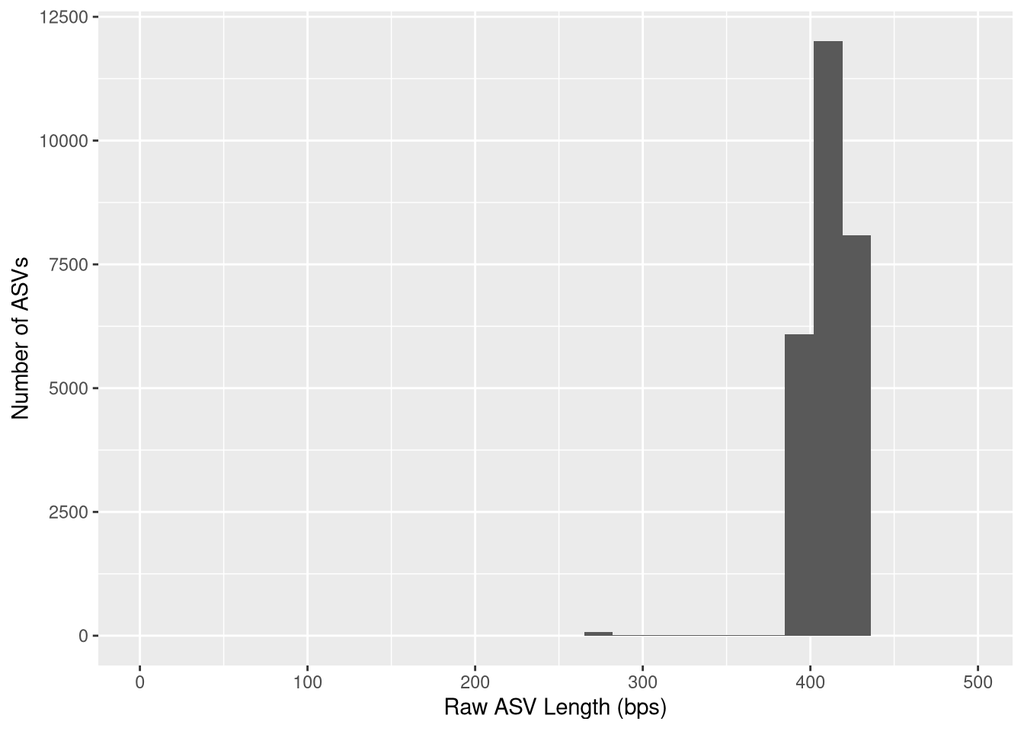

```r
# Inspect the distribution of sequence lengths of all ASVs in data set
# AFTER TRIM
plot_ASVLength_raw <-
  data.frame(Seq_Length = nchar(getSequences(raw_ASV_table))) %>%
  ggplot(aes(x = Seq_Length )) +
  geom_histogram() +
  # include the x-axis scales
  scale_x_continuous(limits = c(0, maxLength_ASV + 5)) +
  labs(y = "Number of ASVs", x = "Raw ASV Length (bps)")

# Show the plot
plot_ASVLength_raw
```

INTERPRETATION #2: Does the ASV length data (table and plot above) match your hypotheses from INTERPRETATION #1? Why or why not? Please insert a description of the interpretation you draw regarding the lengths of your ASVs that you’ve inferred from the ASV length table and it’s graphical visualization above.

Based on the table and histogram, my ASVs are mostly between 397 to 425 base pairs, which are a lot shorter than my hypothesized length. This could be that many of the merged sequences have been truncated due to poor overlap or quality filtering.

INTERPRETATION #3: Taking into account INTERPRETATIONS #1 and #2, what is your suggested trimming procedure for your ASV lengths? Will you allow some variation or trim to an exact length, similar to our in class example here?

I will allow some variation to capture more ASVs.397 to 425 base pairs

## Trim ASV lengths

```r
# Subset only ASVs that are 245 bps long
raw_ASV_table_trimmed <-
  raw_ASV_table[, nchar(colnames(raw_ASV_table)) >= 397 & nchar(colnames(raw_ASV_table)) <= 425]


# Inspect the distribution of sequence lengths of all ASVs in dataset
table(nchar(getSequences(raw_ASV_table_trimmed)))
```

```
##
##  397  398  399  400  401  402  403  404  405  406  407  408  409  410  411  412
##  368  961 2955  831  955  750  153  605  322  193   48   44   12    9   18   15
##  413  414  415  416  417  418  419  420  421  422  423  424  425
##   22   18   21   45   45  641 9053 1488   47    8  524 4918 1079
```

```r
# What proportion of total ASV sequences are left in the data?
percRetained_Trimmed <- sum(raw_ASV_table_trimmed)/sum(raw_ASV_table)
percRetained_Trimmed # Show it
```

```
## [1] 0.9994912
```

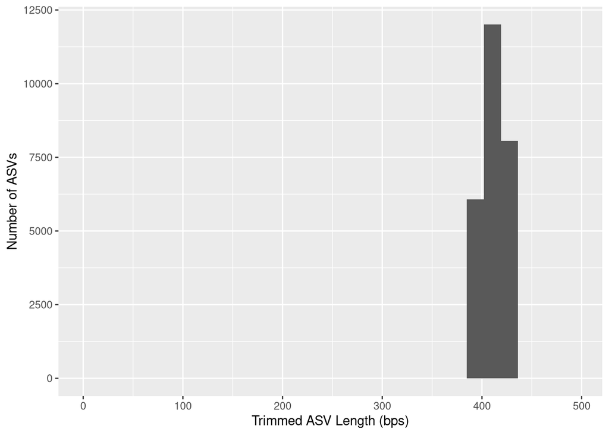

```r
# Inspect the distribution of sequence lengths of all ASVs in dataset
# AFTER TRIM
plot_ASVLength_trimmed <-
  data.frame(Seq_Length = nchar(getSequences(raw_ASV_table_trimmed))) %>%
  ggplot(aes(x = Seq_Length )) +
  geom_histogram() +
  # include the x-axis scales
  scale_x_continuous(limits = c(0, maxLength_ASV + 5)) +
  labs(y = "Number of ASVs", x = "Trimmed ASV Length (bps)")

# Show the plot
plot_ASVLength_trimmed
```

# Remove Chimeras

```r
# Remove the chimeras in the raw ASV table
noChimeras_ASV_table <-
  removeBimeraDenovo(raw_ASV_table_trimmed,
                     method="consensus",
                     multithread = n_threads,
                     verbose=TRUE)
```

```
## Identified 19368 bimeras out of 26148 input sequences.
```

```r
# Check the dimensions
dim(noChimeras_ASV_table)
```

```
## [1]  186 6780
```

```r
# What proportion is left of the sequences?
# Chimera removal compared to trimming
percRetained_chimerasTrimmed <- sum(noChimeras_ASV_table)/sum(raw_ASV_table_trimmed)
# Chimera removal compared to raw
percRetained_chimerasRaw <-sum(noChimeras_ASV_table)/sum(raw_ASV_table)
percRetained_chimerasRaw
```

```
## [1] 0.9620588
```

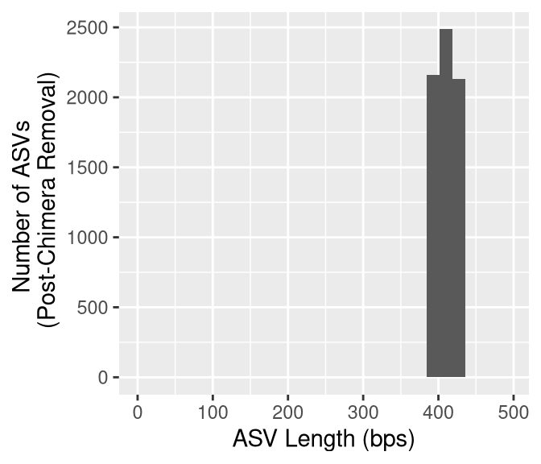

```r
# Plot it
plot_ASVLength_NoChimeras <-
  data.frame(Seq_Length_NoChim = nchar(getSequences(noChimeras_ASV_table))) %>%
  ggplot(aes(x = Seq_Length_NoChim )) +
  geom_histogram()+
  # include the x-axis scales
  scale_x_continuous(limits = c(0, maxLength_ASV + 5)) +
  labs(y = "Number of ASVs \n (Post-Chimera Removal)",
       x = "ASV Length (bps)")

# Show the plot
plot_ASVLength_NoChimeras
```

1. 99.95% of the raw ASVs were retained *after trimming*. 2. 96.25% of the trimmed ASV counts were retained *after chimera removal*. 3. This translates to 96.21% retention of the original, raw merged ASV counts after *both trimming and chimera removal.*

So, there is good retention of the ASVs after length trimming and chimera removal.

INTERPRETATION #4: (1) What proportion of raw ASVs were retained after trimming? (2) What proportion of the trimmed ASVs were retained after chimera removal? (3) What proportion of the total merged ASVs were retained after both trimming and chimera removal? Do you think that the ASV lengths have been trimmed appropriately? For inspiration, you are encouraged to describe the conclusions from the the ASV length plot below.

1. 99.95% of raw ASVs were retained after trimming.
2. 96.25% of the trimmed ASVs were retained after chimera removal.
3. 96.20% of the total merged ASVs were retained after both trimming and chimera removal.

### Plot ASV Lengths

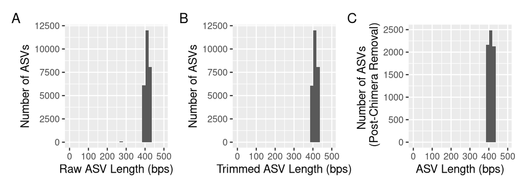

```r
plot_ASVLength_raw + plot_ASVLength_trimmed + plot_ASVLength_NoChimeras +
    plot_annotation(tag_levels = 'A')
```

# Track the read counts

Here, we will look at the number of reads that were lost in the filtering, denoising, merging, and chimera removal.

```r
# A little function to identify number seqs
getN <- function(x) sum(getUniques(x))

# Make the table to track the seqs
track <- cbind(sapply(dada_forward, getN),
               sapply(dada_reverse, getN),
               sapply(merged_ASVs, getN),
               rowSums(noChimeras_ASV_table))

head(track)
```

```
##                                   [,1]  [,2]  [,3]  [,4]
## SRR13675761_R1_filtered.fastq.gz 30444 30625 27722 27391
## SRR13675762_R1_filtered.fastq.gz 46554 47188 40964 40070
## SRR13675763_R1_filtered.fastq.gz 38694 38774 38394 38121
## SRR13675764_R1_filtered.fastq.gz 37124 37415 35837 34141
## SRR13675765_R1_filtered.fastq.gz 29911 29912 29711 28904
## SRR13675766_R1_filtered.fastq.gz   525   520   481   481
```

```r
# Update column names to be more informative (most are missing at the moment!)
colnames(track) <- c("denoisedF", "denoisedR", "merged", "nochim")
rownames(track) <- row.names(noChimeras_ASV_table)

# Generate a dataframe to track the reads through our DADA2 pipeline
track_counts_df <-
  track %>%
  # make it a dataframe
  as.data.frame() %>%
  rownames_to_column(var = "sample_names")

# Now let's add a column for the number of ASVs
# First, intuition check that the samples match
stopifnot(track_counts_df$sample_names == row.names(noChimeras_ASV_table))

# Now, let's add a new column with the number of ASVs
track_counts_df <-
  track_counts_df %>%
  mutate(num_ASVs = rowSums(noChimeras_ASV_table > 1))

# Visualize it in table format
DT::datatable(track_counts_df)
```

|  | sample_names | denoisedF | denoisedR | merged | nochim | num_ASVs |
| --- | --- | --- | --- | --- | --- | --- |
| 1 | SRR13675761_R1_filtered.fastq.gz | 30444 | 30625 | 27722 | 27391 | 689 |
| 2 | SRR13675762_R1_filtered.fastq.gz | 46554 | 47188 | 40964 | 40070 | 1046 |
| 3 | SRR13675763_R1_filtered.fastq.gz | 38694 | 38774 | 38394 | 38121 | 146 |
| 4 | SRR13675764_R1_filtered.fastq.gz | 37124 | 37415 | 35837 | 34141 | 123 |
| 5 | SRR13675765_R1_filtered.fastq.gz | 29911 | 29912 | 29711 | 28904 | 57 |
| 6 | SRR13675766_R1_filtered.fastq.gz | 525 | 520 | 481 | 481 | 35 |
| 7 | SRR13675767_R1_filtered.fastq.gz | 48697 | 49333 | 47360 | 45685 | 229 |
| 8 | SRR13675768_R1_filtered.fastq.gz | 10840 | 10857 | 10682 | 10627 | 80 |
| 9 | SRR13675769_R1_filtered.fastq.gz | 34165 | 34456 | 33126 | 32006 | 109 |
| 10 | SRR13675770_R1_filtered.fastq.gz | 35933 | 36169 | 34898 | 33802 | 131 |

[output cut: 176 more lines]

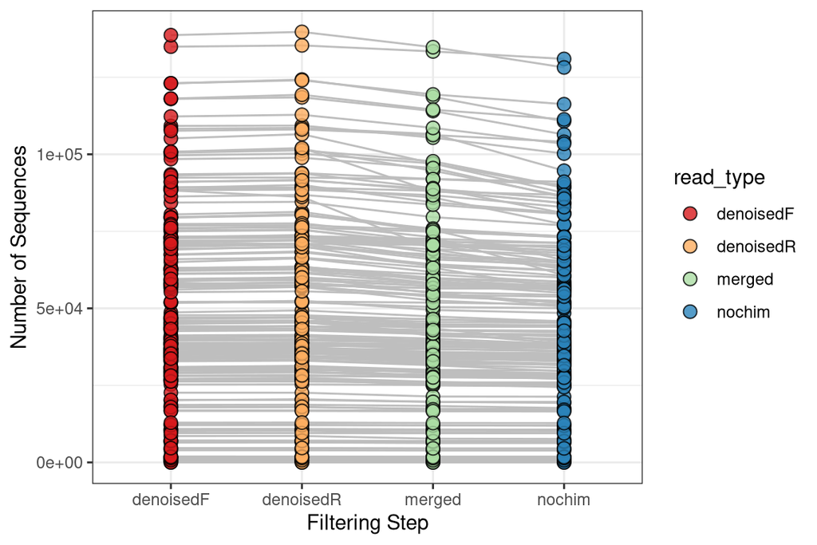

```r
# Plot it!
track_counts_df %>%
  pivot_longer(denoisedF:nochim, names_to = "read_type", values_to = "num_reads") %>%
  mutate(read_type = fct_relevel(read_type, "denoisedF", "denoisedR", "merged", "nochim")) %>%
  ggplot(aes(x = read_type, y = num_reads, fill = read_type)) +
  geom_line(aes(group = sample_names), color = "grey") +
  geom_point(shape = 21, size = 3, alpha = 0.8) +
  scale_fill_brewer(palette = "Spectral") +
  labs(x = "Filtering Step", y = "Number of Sequences") +
  theme_bw()
```

Now, let’s plot the number of sequences that have been maintained in our samples using `geom_histogram()`.

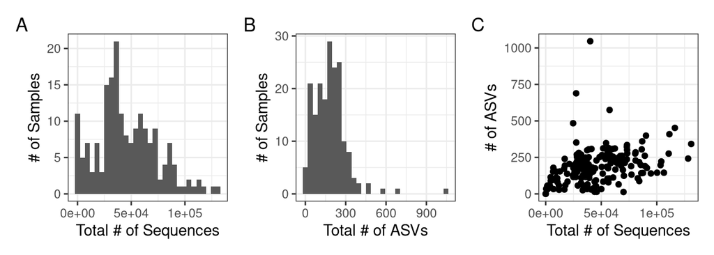

```r
plot_ReadDepth <-
  track_counts_df %>%
  ggplot(aes(x = nochim)) +
  geom_histogram() +
  labs(x = "Total # of Sequences", y = "# of Samples") +
  theme_bw()

# What is the ASV richness per sample?
plot_ASVRichness <-
  track_counts_df %>%
  ggplot(aes(x = num_ASVs)) +
  geom_histogram() +
  labs(x = "Total # of ASVs", y = "# of Samples") +
  theme_bw()

# Now, let's look at the relationship of ASVs and Sequencing depth
plot_ReadDepth_ASVRichness <-
  track_counts_df %>%
  ggplot(aes(x = nochim, y = num_ASVs)) +
  geom_point() +
  labs(x = "Total # of Sequences", y = "# of ASVs") +
  theme_bw()

# Show the plots together
plot_ReadDepth + plot_ASVRichness + plot_ReadDepth_ASVRichness +
    plot_annotation(tag_levels = 'A')
```

The figure above consists of three plots that summarize sequencing depth, ASV richness, and their relationship after DADA2 processing of 16S rRNA gene sequencing data.

**Panel A: Read Depth after DADA2:** Histogram of sequencing depth per sample (Total # of Sequences)

- Most samples have 25000 - 75000 reads per sample.
- A couple of samples have very high read counts (>100000 reads).
- A couple of other samples have very low read counts (~0 reads).

**Panel B: ASV Richness after DADA2:** Histogram of ASV richness (Total # of ASVs per sample)

**Panel C: Read Depth vs ASV Richness:** Scatter plot showing the relationship between sequencing depth and ASV richness.

- There is generally a positive correlation, where samples with higher read depth tend to have more ASVs.
- The positive correlation doesn’t seem to be very strong (the distribution looks a bit flat). This could mean that the dominant species in samples are over-abundant compared to the rarer species.

**Overall Interpretation & Considerations**

1. The sequencing depth of samples is quite variable but with most samples clustering around 30000.
2. A considerable number of samples have low ASV richness, which indicate low read depth or low quality data. 3.The right plot suggests that richness estimates are not very strongly influenced by read depth.

INTERPRETATION #5: What conclusions can you draw from each of the three individual plots above? Please note anything important that the figure might indicate regarding your project data. Are there any specific notes and considerations for later?

# Assign Taxonomy

Here, we will use the **silva database version 138.2**, which has been properly formatted for DADA2. The files came from this [DADA2-formatted reference databases website](https://benjjneb.github.io/dada2/training.html), which hosts several other reference taxomoy files for several popular taxonomic databases.

In this example, we are going to use the database that is pre-downloaded to the server at the following path: `/workdir/in_class_data/taxonomy/`. You are welcome to symbolically link the taxonomy files, however note that they are VERY LARGE. So, it is actually suggested here (for this one time) to use the absolute path here. However, we need to note that this would break our reproducibility!

## How does the taxonomy work?

The `assignTaxonomy` function implements the Ribosomal Database Project (RDP) Naive Bayesian Classifier algorithm described in Wang et al. (2007), published in Applied and Environmental Microbiology, with a kmer size of 8 and 100 bootstrap replicates.

```r
# Assign up to genus level
taxa_train <-
  assignTaxonomy(noChimeras_ASV_table,
                 refFasta = "/workdir/in_class_data/taxonomy/silva_nr99_v138.2_toGenus_trainset.fa.gz",
                 multithread = n_threads)

# Add the genus/species information
taxa_addSpecies <-
  addSpecies(taxa_train,
              refFasta = "/workdir/in_class_data/taxonomy/silva_v138.2_assignSpecies.fa.gz")

# Inspect the taxonomy
glimpse(taxa_addSpecies) # Note that the rownames are the ASV sequences!
```

```
##  chr [1:6780, 1:7] "Bacteria" "Bacteria" "Bacteria" "Bacteria" "Bacteria" ...
##  - attr(*, "dimnames")=List of 2
##   ..$ : chr [1:6780] "GGGAATTTTGGACAATGGGGGCAACCCTGATCCAGCAATGCCGCGTGTGTGAAGAAGGCCTTCGGGTTGTAAAGCACTTTTGTCCGGAAAGAAATCGCACTTACTAATATT"| __truncated__ "GGGAATATTGCACAATGGGCGGAAGCCTGATGCAGCAACGCCGCGTGCGGGATGACGGCCTTCGGGTTGTAAACCGCTTTCGCCTGTGACGAAGCGTGAGTGACGGTAATG"| __truncated__ "GGGAATATTGCACAATG…
##   ..$ : chr [1:7] "Kingdom" "Phylum" "Class" "Order" ...
```

```r
# Let's removing the ASV sequence rownames for display only
taxa_print <- taxa_addSpecies
rownames(taxa_print) <- NULL
head(taxa_print)
```

```
##      Kingdom    Phylum             Class
## [1,] "Bacteria" "Pseudomonadota"   "Gammaproteobacteria"
## [2,] "Bacteria" "Actinomycetota"   "Actinobacteria"
## [3,] "Bacteria" "Pseudomonadota"   "Gammaproteobacteria"
## [4,] "Bacteria" "Campylobacterota" "Campylobacteria"
## [5,] "Bacteria" "Bacillota"        "Bacilli"
## [6,] "Bacteria" "Bacillota"        "Clostridia"
##      Order                                 Family
## [1,] "Burkholderiales"                     "Burkholderiaceae"
## [2,] "Propionibacteriales"                 "Propionibacteriaceae"
## [3,] "Enterobacterales"                    "Enterobacteriaceae"
## [4,] "Campylobacterales"                   "Campylobacteraceae"
## [5,] "Staphylococcales"                    "Staphylococcaceae"
## [6,] "Peptostreptococcales-Tissierellales" "Family XI"
##      Genus                  Species
## [1,] "Ralstonia"            NA
## [2,] "Cutibacterium"        NA
## [3,] "Escherichia-Shigella" NA
## [4,] "Campylobacter"        "hominis"
## [5,] "Staphylococcus"       NA
## [6,] "Fenollaria"           NA
```

```r
#View(taxa_print)
```

# Export the Data

Remember from the beginning of the file under “Goals”, we wanted to export 4 different types of information:

1. ASV Count Table: `asv_table` (with and without sequence names)
2. ASV fasta file: `asvs_fasta` for building a phylogenetic tree at a later step.
3. Taxonomy Table `tax_table`
4. Sample Information: `sample_data` track the reads lots throughout DADA2 workflow.

## 1. ASV Tables

We will export the following two ASV count tables, which will be in “long” format where the **ASVs are in rows** and the **sample names are in the columns.**

### Structure of ASV tables

Let’s check that the ASVs are in the rows and the sample names are in the columns. If not, we can use the transpose function `t()` in R.

```r
# What's the current format of the ASV table?
head(rownames(noChimeras_ASV_table)) # Samples!
```

```
## [1] "SRR13675761_R1_filtered.fastq.gz" "SRR13675762_R1_filtered.fastq.gz"
## [3] "SRR13675763_R1_filtered.fastq.gz" "SRR13675764_R1_filtered.fastq.gz"
## [5] "SRR13675765_R1_filtered.fastq.gz" "SRR13675766_R1_filtered.fastq.gz"
```

```r
head(colnames(noChimeras_ASV_table)) # ASV Sequences
```

```
## [1] "GGGAATTTTGGACAATGGGGGCAACCCTGATCCAGCAATGCCGCGTGTGTGAAGAAGGCC…"
## [2] "GGGAATATTGCACAATGGGCGGAAGCCTGATGCAGCAACGCCGCGTGCGGGATGACGGCC…"
## [3] "GGGAATATTGCACAATGGGCGCAAGCCTGATGCAGCCATGCCGCGTGTATGAAGAAGGCC…"
## [4] "GGGAATATTGCGCAATGGGGGAAACCCTGACGCAGCAACGCCGCGTGGAGGATGACACTT…"
## [5] "GGGAATCTTCCGCAATGGGCGAAAGCCTGACGGAGCAACGCCGCGTGAGTGATGAAGGTC…"
## [6] "GGGAATATTGCACAATGGGGGAAACCCTGATGCAGCGACGCCGCGTGAGCGATGAAGGCT…"
```

```r
# Therefore, we need to transpose the matrix
final_ASV_table_withSeqs <- t(noChimeras_ASV_table)

# Intuition check
head(rownames(final_ASV_table_withSeqs)) # ASV Sequences
```

```
## [1] "GGGAATTTTGGACAATGGGGGCAACCCTGATCCAGCAATGCCGCGTGTGTGAAGAAGGCC…"
## [2] "GGGAATATTGCACAATGGGCGGAAGCCTGATGCAGCAACGCCGCGTGCGGGATGACGGCC…"
## [3] "GGGAATATTGCACAATGGGCGCAAGCCTGATGCAGCCATGCCGCGTGTATGAAGAAGGCC…"
## [4] "GGGAATATTGCGCAATGGGGGAAACCCTGACGCAGCAACGCCGCGTGGAGGATGACACTT…"
## [5] "GGGAATCTTCCGCAATGGGCGAAAGCCTGACGGAGCAACGCCGCGTGAGTGATGAAGGTC…"
## [6] "GGGAATATTGCACAATGGGGGAAACCCTGATGCAGCGACGCCGCGTGAGCGATGAAGGCT…"
```

```r
head(colnames(final_ASV_table_withSeqs)) # Sample names
```

```
## [1] "SRR13675761_R1_filtered.fastq.gz" "SRR13675762_R1_filtered.fastq.gz"
## [3] "SRR13675763_R1_filtered.fastq.gz" "SRR13675764_R1_filtered.fastq.gz"
## [5] "SRR13675765_R1_filtered.fastq.gz" "SRR13675766_R1_filtered.fastq.gz"
```

### Names in ASV tables

#### Fix Sample Names

Notice above that the sample names are actually file names. Let’s fix this!

> WARNING! This is an easy place where a silent error can step in where we could misname our samples, leading to catastrophe down the road. So, we need to be very careful and complete our checks and balances so we ensure the samples are not mixed up in the renaming process.

```r
# Remember at the top of the file we created a vector of sample names
head(sample_names)
```

```
## [1] "SRR13675761" "SRR13675762" "SRR13675763" "SRR13675764" "SRR13675765"
## [6] "SRR13675766"
```

```r
# Let's check with the actual column names
head(colnames(final_ASV_table_withSeqs)) # Sample names
```

```
## [1] "SRR13675761_R1_filtered.fastq.gz" "SRR13675762_R1_filtered.fastq.gz"
## [3] "SRR13675763_R1_filtered.fastq.gz" "SRR13675764_R1_filtered.fastq.gz"
## [5] "SRR13675765_R1_filtered.fastq.gz" "SRR13675766_R1_filtered.fastq.gz"
```

```r
# And then apply our sample name script to check, too
head(sapply(strsplit(colnames(final_ASV_table_withSeqs), "_"), `[`,1)) # Looks good!
```

```
## [1] "SRR13675761" "SRR13675762" "SRR13675763" "SRR13675764" "SRR13675765"
## [6] "SRR13675766"
```

```r
# Now, add a break in the script break if this isn't true!
# Let's make sure the sample names match the file names in the matrix.
stopifnot(sapply(strsplit(colnames(final_ASV_table_withSeqs), "_"), `[`,1) == sample_names)

# Now, we've done some checks to prove to ourselves there will be no silent errors,
# Let's rename!
colnames(final_ASV_table_withSeqs) <- sample_names
head(colnames(final_ASV_table_withSeqs))
```

```
## [1] "SRR13675761" "SRR13675762" "SRR13675763" "SRR13675764" "SRR13675765"
## [6] "SRR13675766"
```

#### Rename ASVs

Then, we can also fix the names of our ASVs for our second ASV table where we will replace the ASV sequence names with ASV_1, ASV_2

```r
# Give headers more manageable names
# First pull the ASV sequences from the rownames
ASV_seqs <- rownames(final_ASV_table_withSeqs)
ASV_seqs[1:5]
```

```
## [1] "GGGAATTTTGGACAATGGGGGCAACCCTGATCCAGCAATGCCGCGTGTGTGAAGAAGGCC…"
## [2] "GGGAATATTGCACAATGGGCGGAAGCCTGATGCAGCAACGCCGCGTGCGGGATGACGGCC…"
## [3] "GGGAATATTGCACAATGGGCGCAAGCCTGATGCAGCCATGCCGCGTGTATGAAGAAGGCC…"
## [4] "GGGAATATTGCGCAATGGGGGAAACCCTGACGCAGCAACGCCGCGTGGAGGATGACACTT…"
## [5] "GGGAATCTTCCGCAATGGGCGAAAGCCTGACGGAGCAACGCCGCGTGAGTGATGAAGGTC…"
```

```r
# How many ASVs?
num_ASVs <- dim(final_ASV_table_withSeqs)[1] # select the number of rows
num_ASVs
```

```
## [1] 6780
```

```r
# Make an empty vector the length of the number of ASVs,
# which is where we will place the new operational ASV names
ASV_headers <- vector(num_ASVs, mode = "character")

# Let's mae sure we have an empty vector!
ASV_headers[1:5]
```

```
## [1] "" "" "" "" ""
```

```r
length(ASV_headers) # looks good!
```

```
## [1] 6780
```

```r
# Now, let's create a vector with ASV numbers
# loop through vector and fill it in with ASV names
for (i in 1:num_ASVs) {
  # Add leading zero to ASV name so they print in correct order.
  ASV_number <- sprintf("%04d", i)
  # Now, rename each spot in the ASV header vector as we loop through the for loop
  ASV_headers[i] <- paste(">ASV", ASV_number, sep = "_")
}

# Intuition check
ASV_headers[1:5]
```

```
## [1] ">ASV_0001" ">ASV_0002" ">ASV_0003" ">ASV_0004" ">ASV_0005"
```

```r
# Create a new ASV table, which will have the ASV numbers as names
# View(noChimeras_ASV_table) # To view the table2
final_ASV_table <- final_ASV_table_withSeqs
glimpse(final_ASV_table)
```

```
##  int [1:6780, 1:186] 11 141 32 12 40 102 20 521 5 21 ...
##  - attr(*, "dimnames")=List of 2
##   ..$ : chr [1:6780] "GGGAATTTTGGACAATGGGGGCAACCCTGATCCAGCAATGCCGCGTGTGTGAAGAAGGCCTTCGGGTTGTAAAGCACTTTTGTCCGGAAAGAAATCGCACTTACTAATATT"| __truncated__ "GGGAATATTGCACAATGGGCGGAAGCCTGATGCAGCAACGCCGCGTGCGGGATGACGGCCTTCGGGTTGTAAACCGCTTTCGCCTGTGACGAAGCGTGAGTGACGGTAATG"| __truncated__ "GGGAATATTGCACAATG…
##   ..$ : chr [1:186] "SRR13675761" "SRR13675762" "SRR13675763" "SRR13675764" ...
```

```r
## Replace the ASV seqs with the ASV numbers
row.names(final_ASV_table) <- sub(">", "", ASV_headers)
final_ASV_table[1:5, 1:5]
```

```
##          SRR13675761 SRR13675762 SRR13675763 SRR13675764 SRR13675765
## ASV_0001          11           0           3           0           0
## ASV_0002         141        9451         506           0           0
## ASV_0003          32          17         439        2126           0
## ASV_0004          12           0         113         184           4
## ASV_0005          40          65       21933           0           0
```

```r
#View(final_ASV_table) # To view the table
```

### Write the ASV Tables!

```r
# 1. Write count table with ASV sequence names
write.table(final_ASV_table_withSeqs,
            file = "data/01_DADA2/ASV_table_withSeqNames.tsv",
            sep = "\t", quote = FALSE, col.names = NA)

# 2. Write count table with ASV numbered names (e.g. ASV_1, ASV_2, etc)
write.table(final_ASV_table,
            file = "data/01_DADA2/ASV_table.tsv",
            sep = "\t", quote = FALSE, col.names = NA)
```

## 2. ASV Fasta File

Now, let’s create a fasta file that has our ASV numbers with each of their corresponding ASV sequences. This file needs to be created because we will use it later to build a phylogenetic tree.

**Why do we need a phylogenetic tree?** Many widely used microbial ecology metrics rely on phylogenetic relationships to quantify community similarity. For example, there are phylogenetic alpha-diversity metrics like the [phylogenetic Hill Numbers](https://www.annualreviews.org/content/journals/10.1146/annurev-ecolsys-120213-091540) and also beta-diversity measures that incorporate the branch lenghts of phylogenetic trees as it relates to community dissimimlarity, [like the abundance-unweighted and abundance-weighted UniFrac dissimilarity metrics](https://journals.asm.org/doi/full/10.1128/aem.71.12.8228-8235.2005). These metrics consider species presence and their evolutionary distances, conveying relationships of communities through an ecological *and* evolutionary framework.

### Write the ASV Fasta File

```r
# Let's take our asv_headers
head(ASV_headers, n = 2)
```

```
## [1] ">ASV_0001" ">ASV_0002"
```

```r
# And combine it with their sequences
head(ASV_seqs, n = 2)
```

```
## [1] "GGGAATTTTGGACAATGGGGGCAACCCTGATCCAGCAATGCCGCGTGTGTGAAGAAGGCC…"
## [2] "GGGAATATTGCACAATGGGCGGAAGCCTGATGCAGCAACGCCGCGTGCGGGATGACGGCC…"
```

```r
# Combine in a fasta format with the cbind() function
ASV_fasta <- c(rbind(ASV_headers, ASV_seqs))
head(ASV_fasta, n = 4)
```

```
## [1] ">ASV_0001"
## [2] "GGGAATTTTGGACAATGGGGGCAACCCTGATCCAGCAATGCCGCGTGTGTGAAGAAGGCC…"
## [3] ">ASV_0002"
## [4] "GGGAATATTGCACAATGGGCGGAAGCCTGATGCAGCAACGCCGCGTGCGGGATGACGGCC…"
```

```r
# Then, let's write it to a fasta file!
# This will be our reference later on for which seq matches which ASV
write(ASV_fasta, "data/01_DADA2/ASVs.fasta")
```

## 3. Taxonomy Table

Before we actually write the taxonomy table, let’s put the ASV sequences as another column in our taxonomy table and then replace the rownames to be our numbered ASV names.

### Reformat Taxonomy

1. Move ASV sequences to column
2. Replace ASV rownames with ASV numbered names

> WARNING! This is another easy place where a silent error can step in!! Here, we could accidentally misname our ASVs. So, we need to be very careful and perform intuition checks to ensure that the ASV names are not mixed up in the renaming process.

```r
# Inspect the taxonomy table
dim(taxa_addSpecies) # ASVs are in rows and Kingdom, Phylum, etc in Columns
```

```
## [1] 6780    7
```

```r
colnames(taxa_addSpecies) # Column names are Linnean Taxonomy
```

```
## [1] "Kingdom" "Phylum"  "Class"   "Order"   "Family"  "Genus"   "Species"
```

```r
head(rownames(taxa_addSpecies), n = 2) # ASV names are rownames
```

```
## [1] "GGGAATTTTGGACAATGGGGGCAACCCTGATCCAGCAATGCCGCGTGTGTGAAGAAGGCC…"
## [2] "GGGAATATTGCACAATGGGCGGAAGCCTGATGCAGCAACGCCGCGTGCGGGATGACGGCC…"
```

```r
class(taxa_addSpecies) # Character matrix
```

```
## [1] "matrix" "array"
```

```r
##### Prepare tax table
# 1. Add the ASV sequences from the rownames to a column
new_tax_table <-
  taxa_addSpecies%>%
  as.data.frame() %>%
  rownames_to_column(var = "ASVseqs")

# Intuition check
glimpse(new_tax_table)
```

```
## Rows: 6,780
## Columns: 8
## $ ASVseqs <chr> "GGGAATTTTGGACAATGGGGGCAACCCTGATCCAGCAATGCCGCGTGTGTGAAGAAGGCCT…
## $ Kingdom <chr> "Bacteria", "Bacteria", "Bacteria", "Bacteria", "Bacteria", "B…
## $ Phylum  <chr> "Pseudomonadota", "Actinomycetota", "Pseudomonadota", "Campylo…
## $ Class   <chr> "Gammaproteobacteria", "Actinobacteria", "Gammaproteobacteria"…
## $ Order   <chr> "Burkholderiales", "Propionibacteriales", "Enterobacterales", …
## $ Family  <chr> "Burkholderiaceae", "Propionibacteriaceae", "Enterobacteriacea…
## $ Genus   <chr> "Ralstonia", "Cutibacterium", "Escherichia-Shigella", "Campylo…
## $ Species <chr> NA, NA, NA, "hominis", NA, NA, NA, NA, "merdae", "magna", "cor…
```

```r
# IMPORTANT! Let's do our intuition check
# This is where we ensure we don't mix up the ASV names!
stopifnot(new_tax_table$ASVseqs == rownames(final_ASV_table_withSeqs))

# Now let's add the ASV names
rownames(new_tax_table) <- rownames(final_ASV_table)
head(new_tax_table)
```

```
##                                                                                                                                                                                                                                                                                                          …
## ASV_0001 GGGAATTTTGGACAATGGGGGCAACCCTGATCCAGCAATGCCGCGTGTGTGAAGAAGGCC…
## ASV_0002                     GGGAATATTGCACAATGGGCGGAAGCCTGATGCAGCAACGCCGCGTGCGGGATGACGGCC…
## ASV_0003 GGGAATATTGCACAATGGGCGCAAGCCTGATGCAGCCATGCCGCGTGTATGAAGAAGGCC…
## ASV_0004                         GGGAATATTGCGCAATGGGGGAAACCCTGACGCAGCAACGCCGCGTGGAGGATGACACTT…
## ASV_0005 GGGAATCTTCCGCAATGGGCGAAAGCCTGACGGAGCAACGCCGCGTGAGTGATGAAGGTC…
## ASV_0006                          GGGAATATTGCACAATGGGGGAAACCCTGATGCAGCGACGCCGCGTGAGCGATGAAGGCT…
##           Kingdom           Phylum               Class
## ASV_0001 Bacteria   Pseudomonadota Gammaproteobacteria
## ASV_0002 Bacteria   Actinomycetota      Actinobacteria
## ASV_0003 Bacteria   Pseudomonadota Gammaproteobacteria
## ASV_0004 Bacteria Campylobacterota     Campylobacteria
## ASV_0005 Bacteria        Bacillota             Bacilli
## ASV_0006 Bacteria        Bacillota          Clostridia
##                                        Order               Family
## ASV_0001                     Burkholderiales     Burkholderiaceae
## ASV_0002                 Propionibacteriales Propionibacteriaceae
## ASV_0003                    Enterobacterales   Enterobacteriaceae
## ASV_0004                   Campylobacterales   Campylobacteraceae
## ASV_0005                    Staphylococcales    Staphylococcaceae
## ASV_0006 Peptostreptococcales-Tissierellales            Family XI
##                         Genus Species
## ASV_0001            Ralstonia    <NA>
## ASV_0002        Cutibacterium    <NA>
## ASV_0003 Escherichia-Shigella    <NA>
## ASV_0004        Campylobacter hominis
## ASV_0005       Staphylococcus    <NA>
## ASV_0006           Fenollaria    <NA>
```

```r
### Final prep of tax table. Add new column with ASV names
ASV_tax_table <-
  new_tax_table %>%
  # add rownames from count table for phyloseq handoff
  mutate(ASV = rownames(final_ASV_table)) %>%
  # Reorder the columns
  dplyr::select(Kingdom, Phylum, Class, Order, Family, Genus, Species, ASV, ASVseqs)

# Assign the rownames, which is required by phyloseq
rownames(ASV_tax_table) <- ASV_tax_table$ASV

# Take a quick look
glimpse(ASV_tax_table)
```

```
## Rows: 6,780
## Columns: 9
## $ Kingdom <chr> "Bacteria", "Bacteria", "Bacteria", "Bacteria", "Bacteria", "B…
## $ Phylum  <chr> "Pseudomonadota", "Actinomycetota", "Pseudomonadota", "Campylo…
## $ Class   <chr> "Gammaproteobacteria", "Actinobacteria", "Gammaproteobacteria"…
## $ Order   <chr> "Burkholderiales", "Propionibacteriales", "Enterobacterales", …
## $ Family  <chr> "Burkholderiaceae", "Propionibacteriaceae", "Enterobacteriacea…
## $ Genus   <chr> "Ralstonia", "Cutibacterium", "Escherichia-Shigella", "Campylo…
## $ Species <chr> NA, NA, NA, "hominis", NA, NA, NA, NA, "merdae", "magna", "cor…
## $ ASV     <chr> "ASV_0001", "ASV_0002", "ASV_0003", "ASV_0004", "ASV_0005", "A…
## $ ASVseqs <chr> "GGGAATTTTGGACAATGGGGGCAACCCTGATCCAGCAATGCCGCGTGTGTGAAGAAGGCCT…
```

```r
# Intution check
stopifnot(ASV_tax_table$ASV == rownames(ASV_tax_table),
          rownames(ASV_tax_table) == rownames(ASV_tax_table))
```

### Write the Taxonomy Table

```r
# Write the table
write.table(ASV_tax_table,
            file = "data/01_DADA2/ASV_taxonomy.tsv",
            sep = "\t", quote = FALSE, col.names = NA)
```

## 4. Sample Data

Let’s save the `track_counts_df`, which can be useful for downstream analyses.

```r
# And save the track_counts_df a R object, which we will merge with metadata information in the next step of the analysis in nalysis/02_Taxonomic_Assignment.
save(track_counts_df, file = "data/01_DADA2/track_read_counts.RData")
```

# Final info for Reproducibility

## Check Render Time

```r
# Take the time now that we are at the end of the script
end_time <- Sys.time()
end_time
```

```
## [1] "2025-03-11 09:41:54 EDT"
```

```r
# Echo the elapsed time
elapsed_time <- round((end_time - start_time), 3)
elapsed_time
```

```
## Time difference of 25.083 mins
```